# Presentation_2dot0

13 5 2019

## Motivation

## Motivation

Let’s take a look at the following bivariate sample:

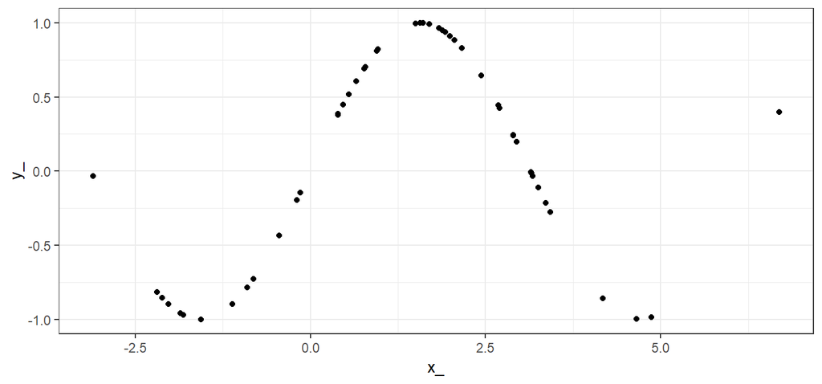

which we obtained from \(X \sim \mathcal{N}(1.42,2)\) and \(Y = \sin(X)\).

Would it be easier to predict \(Y\) given \(X\), or \(X\) given \(Y\)?

## Motivation cont.

So, we saw how we could have an asymmetrical dependence structure.

This is not a constructed problem, as the following example shows:

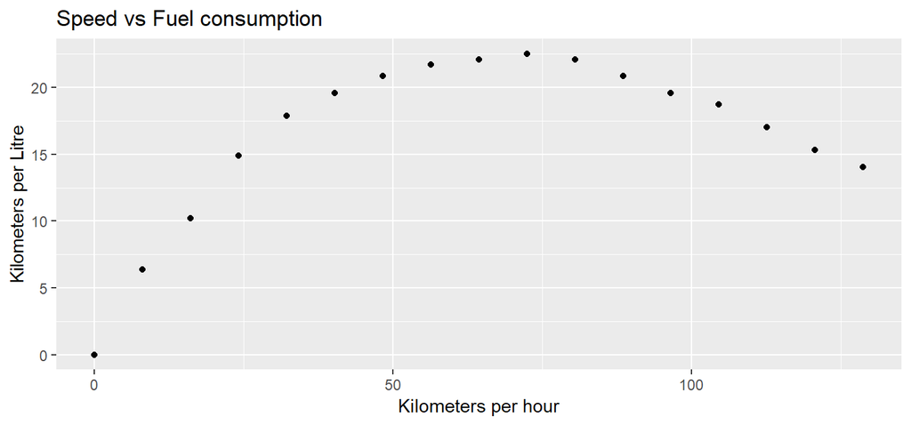

## Motivation cont.

So, why could this be a problem?

How would you usually try to quantify dependence?

## Motivation cont.

So, why could this be a problem?

How would you usually try to quantify dependence?

Correlation comes to mind.

Let’s try it:

```r
cor(x_,y_)
```

```
## [1] 0.2870855
```

```r
cor(y_,x_)
```

```
## [1] 0.2870855
```

## Motivation cont.

We got the same value. Indeed, by the Definition of correlation (or covariance), we will always get \(r(X,Y) = r(Y,X)\). The same happens, if we calculated the spearman or kendall correlation instead (same problem).

It seems, that correlation is not applicable to measure asymmetric dependence.

We would like to have a dependency measure, that can also classify asymmetric dependency. How could we go about obtaining/constructing one?

## Motivation cont.

What would we like for such a dependency measure, say *q*?

- \(q(X,Y) \in [0,1]\)
- \(q(X,Y) = 0\) if and only if \(X\) and \(Y\) are independent (independence)
- \(q(X,Y) = 1\) if and only if \(Y\) is a function of \(X\) (complete dependence)

We want a higher \(q(X,Y)\), if there is a higher dependency of \(Y\) on \(X\). It may well be, that \(q(X,Y) \neq q(Y,X)\).

Additionally, scale changes should not affect the outcome.

## Outline of the qad-measure’s construction:

- Start with a bivariate sample
- Use the pseudo-observations to construct the empirical copula \(E_n\).
- Aggregate \(E_n\) to the empirical checkerboard copula \(\hat{C_n}\).
- Estimate \(q(A) = 3 D_1(A,\Pi)\) via \(q(\hat{C_n}) = 3 D_1(\hat{C_n},\Pi)\).
- For sufficiently large \(n\), we have \(q(\hat{C_n}) \approx q(A)\).

## (Empirical) Copula

## Idea

The thing is, we already have a link between univariate and bivariate distributions, which contains all the information about mutual dependency: Copulae (literally: copula is latin for “link”).

Math guarantees us it’s existance, therefore it makes sense to try and use this for our dependency measure.

Now, math gives us the existence of such a copula, say, \(A\), that we could use to measure dependency. But how do we get \(A\) from a given bivariate sample?

## Empirical copula

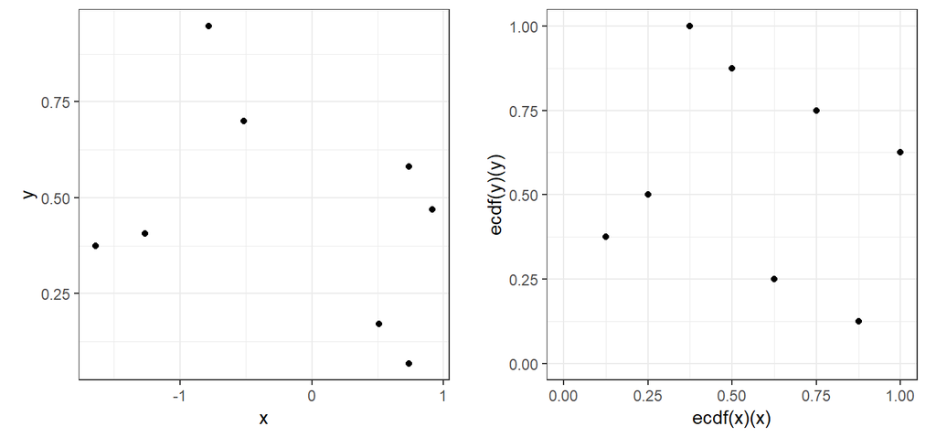

The idea is (somewhat) similar to the empirical distribution:

We start with a sample \((x_1, y_1), \dots, (x_n, y_n)\) and the pseudo - observations (normalized ranks).

## Empirical copula cont.

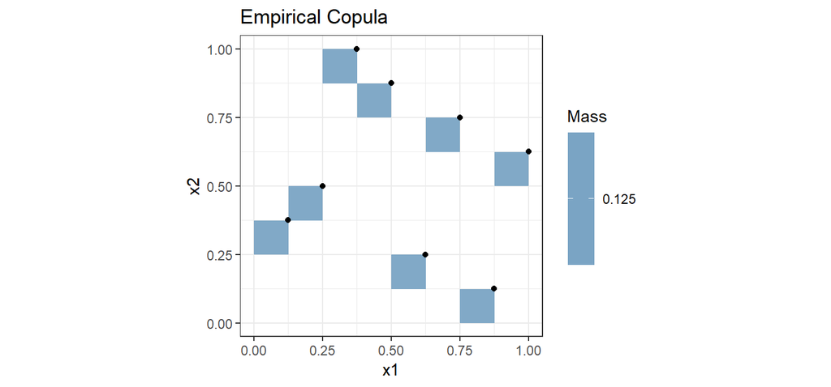

And then proceed to construct an empirical copula as shown above.

## Empirical copula of our example

Let’s compute the empirical copula for our example:

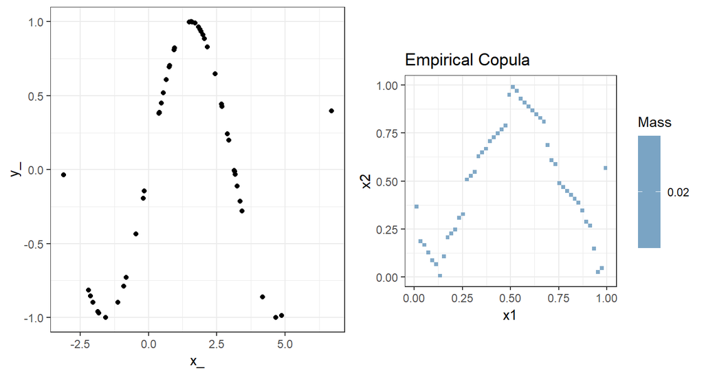

## Limitations

We hope or empirical copula \(E_n\) to be a good estimate for the “true” one \(A\).

However, as it turns out, using the very metric \(D_1\) of our dependency measure \(q\), it is not (always).

So, we need to come up with something.

## Empirical checkerboard copula

The expedient is to “aggregate” the empirical copula into what we call empirical checkerboard copula.

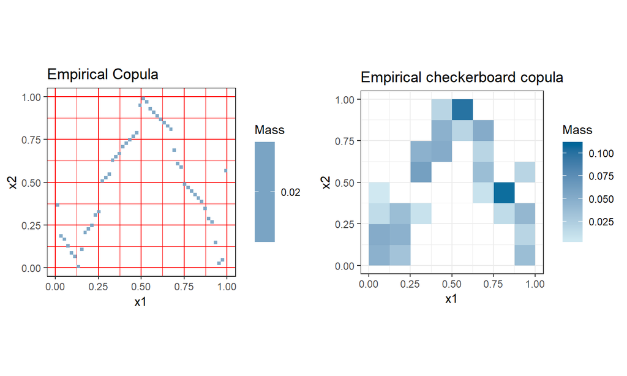

Now, not only does the checkerboard copula \(\hat{C_n}\) have nice analytical properties, it also is a good estimate for \(A\) in our metric \(D_1\), so \(D_1(\hat{C_n},A) \approx 0\) for sufficiently large \(n\).

## emp_c_copula

The function *emp_c_copula* computes the mass-distribution of the empirical (checkerboard) copula, given a bivariate sample. It returns a matrix with the mass distribution.

Arguments:

- X: a dataframe containing a bivariate sample in two columns, one row contains one observation.
- smoothing: a logical indication whether the checkerboard copula is to be calculated
- resolution: an integer indicating the resolution of the checkerboard aggregation (the number of breaks in the grid)

## plot_density

The function *plot_density* plots the density/mass of the empirical (checkerboard) copula.

Arguments:

- mass_matrix: A squared matrix containing the mass distribution
- density: A logical whether the density or mass is plotted

## Exercise 1

Try to calculate the empirical copula – not the checkerboard one – while having the argument *smoothing=TRUE*. Why does this work in this particular case?

Optional: Try to explain by also plotting the pseudo observations of your generated sample into the mass-plot (also testing your *ggplot* skills a bit here).

Also, try to explain the differences in the following plots:

```r
n=10
df = data.frame(x = rnorm(n), y = runif(n))
emp_cop = emp_c_copula(df, smoothing = FALSE)
emp_check_cop = emp_c_copula(df, smoothing = TRUE, resolution = 20)
plot_density(emp_cop, density = FALSE)
plot_density(emp_check_cop, density = FALSE)
```

## The dependency measure

## The dependency measure

Based on a metric \(D_1\) for copulae, a dependency measure can be constructed in the following way: \[ q(A) := 3\cdot D_1(A,\Pi) \; \in [0,1] \] \(\Pi\) denotes the product copula, which stands for complete independence of two RVs.

In a way, we measure the “distance” to complete independece.

## qad

The function *qad* quantifies the asymmetric dependence structure of two RVs \(X\) and \(Y\). It does so by calculating the empirical checkerboard copula to estimate the dependency measure \(q\).

Arguments:

- X: a dataframe containing a bivariate sample in two columns. Each row contains one observation. alternative: two numeric vectors \(x\) and \(y\).
- resolution: an integer indicating the resolution of the checkerboard aggregation. Default (=NULL) uses the optimal.
- premutation: a logical indicating, whether a permutated \(p\)-value is computed.

## qad cont.

If you run a permutation \(p\) test, you can indicate the number of permutation runs (nperm) and whether you want it to be computed in parallel (DoParallel) using multiple cores (ncores, Default=NULL uses max-1).

Via the option print=TRUE you can print the result into the console.

Alternatively, you can use the *summary*- function on the qad-object returned by *qad*

## qad Example

Now, let’s go back to our initial sample:

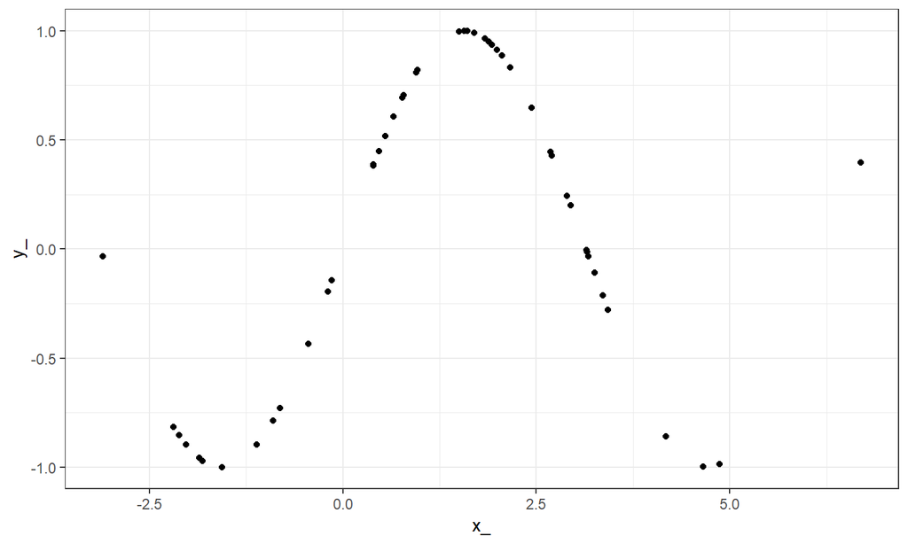

## qad Example

And take a look at the mutual dependencies.

```r
mod = qad(X, print = FALSE)
coef(mod, select = c("q(x1,x2)","q(x2,x1)","mean.dependence",
                     "asymmetry"))
```

```
##        q(x1,x2)        q(x2,x1) mean.dependence       asymmetry
##       0.7885979       0.4193818       0.6039898       0.3692161
```

Now, the fact that we would rather use \(X\) to predict \(Y\) instead of the other way around is reflected.

## pairwise.qad

With the function *pairwise.qad*, we can apply the *qad* function on each pair of columns of the given dataframe. The other arguments are the same as for *qad*.

```r
n = 1000
x = runif(n,0,1)
y = x^2+rnorm(n,0,1)
z = runif(n,0,1)
df = data.frame(x,y,z)

model = pairwise.qad(df, permutation = TRUE, nperm = 10,
                     DoParallel = TRUE)
```

```
## [1] "Process..."
## [1] "Process: 1 / 3"
## [1] "Process: 2 / 3"
```

## heatmap.qad

We can then plot the results into a heatmap:

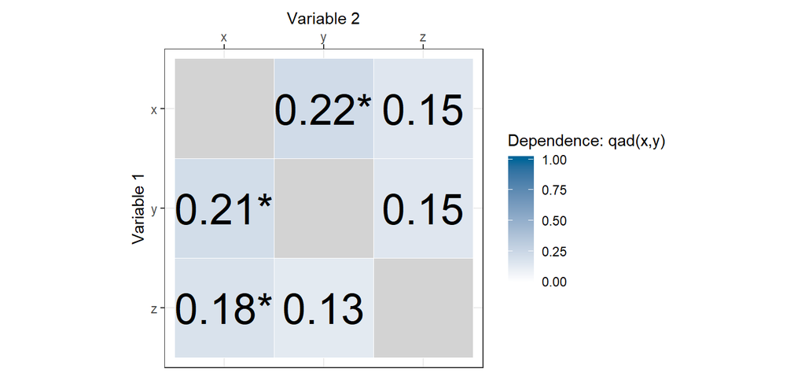

```r
heatmap.qad(model, select = "dependence", fontsize = 10,
            significance = TRUE)
```

## heatmap.qad

Arguments:

- pw_qad: the output of the function *pairwise.qad()*
- select: a character, which dependence value is plotted: “dependence”, “mean.dependence” or “asymmetry”
- fontsize: a numeric for the size of the values
- significance: logical; if p-values were calculated, marks the significant dependency values with a star
- sign.level: manually set significance level (default: 0.05)
- scale: “rel” or “abs”, use a relative or absolute scale; default: “abs”

## Exercise 2

- Download the RTR-dataset

  (via load(url(“http://www.trutschnig.net/RTR.RData”)) )

  and sample 1000 observations
- Examine which columns could have interesting dependencies
- Not for all columns, this makes sense (why?)
- Visualize the dependencies for the relevant columns. Argue, why you chose them.

## plot.qad

Plots conditional probabilities for each strip of the checkerboard copula in the copula setting,

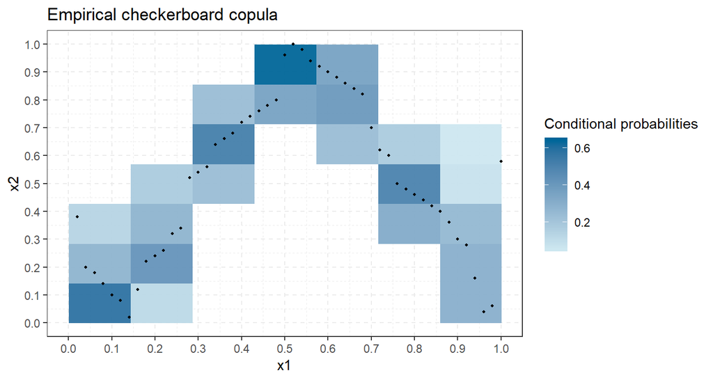

## plot.qad

Plots conditional probabilities for each strip of the checkerboard copula in the copula setting,

or the retransformed data setting.

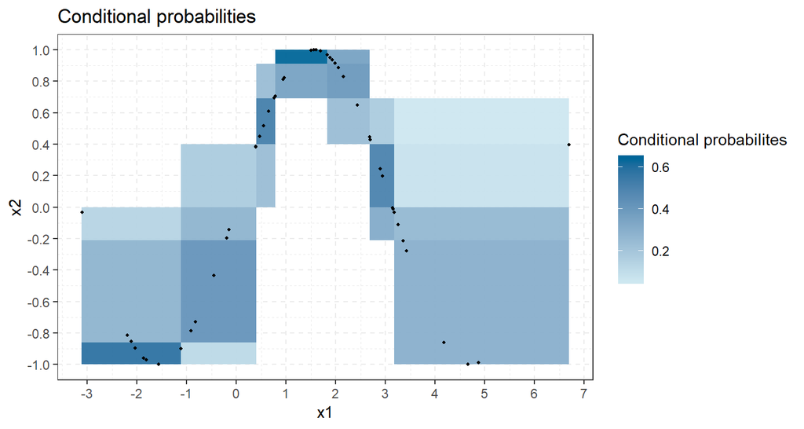

## predict.qad

The function *predict.qad()* predicts the probabilities to end up in specific intervals given \(x\) or \(y\) values and plots the conditional probabilities.

The prediciton can again be computed in the copula or the retransformed data setting.

```r
predict(mod, values = 1.42, conditioned = "x1", nr_intervals = 5)
```

```
##      (-1,-0.79] (-0.79,-0.02] (-0.02,0.43] (0.43,0.82] (0.82,1]
## 1.42          0             0            0       0.216    0.784
```

## Exercise 3

- Create a dummy dataset: n=100 observations of a uniformly distributed random variable and the corresponding square values.
- Create a new qad object and use the plot function to visualize the copula.
- Add the observations to the plot with the addSample parameter.
- Use the predict.qad method and sum up the probabilities for one strip (horizontal or vertical) for one value

## cci

We can use the qad metric to test hypothesis:

cci (conditional confidence interval) provides a confidence interval for independence (for the qad measure).

Therefore, we can compare the qad-value to the interval boundaries and check if the null hypothesis of independence holds or has to be rejected.

## cci

So, we calculate our boundaries

```r
c = cci(n, alternative = "one.sided")
```

and check, whether our calculated dependence for our example lies in between.

```r
if(coef(mod, select = 'q(x1,x2)') %in% c){
 print(paste('q(x1,x2)','in [',c[1],', ', c[2], ']',sep=' '))
 print('Accept H0')
}else{
 print(paste('q(x1,x2)','not in [',c[1],',', c[2], ']',sep=' '))
 print('Reject H0')
}
```

## cci

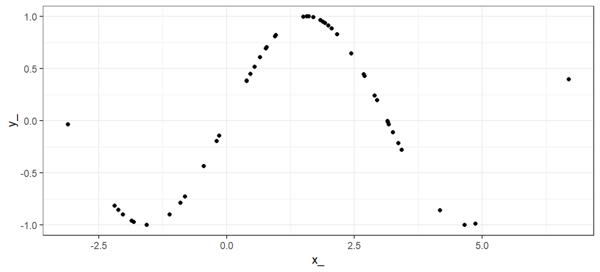

And indeed, for our example, we reject the hypothesis of independence:

```
## [1] "q(x1,x2) not in [ 0 , 0.1813481327652 ]"
## [1] "Reject H0"
```

## cci

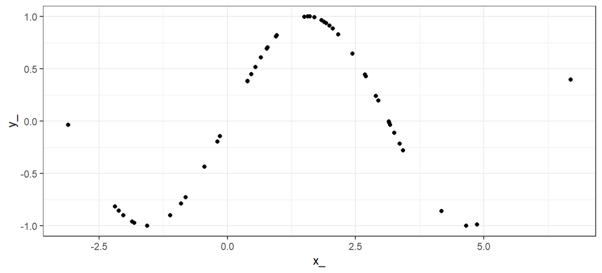

Same for the other direction:

```
## [1] "q(x2,x1) not in [ 0 , 0.1813481327652 ]"
## [1] "Reject H0"
```

## Final Exercise:

Take a look at the *attitude* dataset:

Find out the two sets with the highest (one sided) dependency. Provide respective plots.

Are those dependencies symmetric? Argue by providing p-values for asymmetry (hint: it may be wise not to calculate the p-values for all pairs, only the chosen two)

Reject or Accept the hypothesis of independence for your chosen pairs.